# Solution to Homework 7

STATS/DATASCI 531

## Question 7.1. Introduction to the greatlakes cluster.

- Some Windows users had difficulties with PuTTY. Another way to access a terminal on greatlakes is to connect to https://greatlakes.arc-ts.umich.edu/ and follow the menu option to `Clusters` $\rightarrow$ `Great Lakes login node`. You must be on campus or running a VPN to log in.
- On my MacBook Air laptop, times from running `Rscript test.R`, or equivalently `source(test.R)` within an R session, are

```
##       user.self sys.self elapsed user.child sys.child
## time0     6.424    0.231   6.716      0.000     0.000
## time1     0.390    0.874   6.468      8.271     1.239
## time2     0.425    0.916   7.678      0.000     0.000
## time3     0.493    0.779   5.715     13.356     1.629
## time4     1.680    0.922   8.053     14.133     2.185
```

- On greatlakes, from running `sbatch test.sbat`, you get

```
##       user.self sys.self elapsed user.child sys.child
## time0     6.370    0.266   6.652      0.000     0.000
## time1     0.210    0.829   2.003      0.683     0.123
## time2     0.213    0.791   1.384      1.092     0.262
## time3     0.311    0.645   1.400      6.802     1.869
## time4     1.047    0.947   2.235      6.976     2.755
```

- For this task, using 36 cores does not speed up the computing by a factor of 36. Best results from parallelization are obtained when each task in the for loop is relatively large, reducing the overhead required to set up the parallel tasks and communicate between them. In this particular example, each task is small and so the overhead can be considerable. For a 4 core laptop, we see little or no advantage of parallelization in this particular case.

## Question 7.2. Likelihood maximization for the SEIR model.

### (a). Developing the model and the likelihood maximization procedure

We follow the solutions from Simulation-Based Inference for Epidemiological Dynamics [1] Lesson 4 . We start by building a pomp object for the SEIR model from Homework 6, using as a starting point the SIR code from the notes.

```r
library(pomp)
library(tidyverse)
library(doParallel)
library(doRNG)
source("https://kingaa.github.io/sbied/pfilter/model.R")
start_time <- Sys.time()
```

```r
seir_step <- Csnippet("
  double dN_SE = rbinom(S,1-exp(-Beta*I/N*dt));
  double dN_EI = rbinom(E,1-exp(-mu_EI*dt));
  double dN_IR = rbinom(I,1-exp(-mu_IR*dt));
  S -= dN_SE;
  E += dN_SE - dN_EI;
  I += dN_EI - dN_IR;
  R += dN_IR;
  H += dN_IR;
")

seir_rinit <- Csnippet("
  S = nearbyint(eta*N);
  E = 0;
  I = 1;
  R = nearbyint((1-eta)*N);
  H = 0;
")

measSEIR <- pomp(measSIR,
  rprocess=euler(seir_step,delta.t=1/7),
  rinit=seir_rinit,
  paramnames=c("N","Beta","mu_EI","mu_IR","eta","k","rho"),
  partrans=parameter_trans(
        log=c("Beta","mu_EI","mu_IR","k"),
        logit=c("eta","rho")
  ),
  statenames=c("S","E","I","R","H")
)
```

Now, we’ll start by considering the best parameters we’ve found so far, for the regime where $\mu_{IR}=2\mathrm{wk}^{-1}$. We extract these from the database used for the notes.

```r
read_csv("https://kingaa.github.io/sbied/mif/measles_params.csv") %>%
  filter(
    loglik==max(loglik),
    abs(mu_IR-2)<0.001
    ) %>%
  select(-loglik,-loglik.se) -> coef(measSEIR)

coef(measSEIR,"mu_EI") <- 0.8
```

```
## Warning: in 'coef<-': name 'mu_EI' refers to no existing parameter; it is being
## concatenated.
```

```r
fixed_params <- coef(measSEIR,c("N","mu_IR","k"))
coef(measSEIR)
```

```
##         Beta        mu_IR          rho            k          eta            N
## 3.629251e+00 2.000000e+00 5.569420e-02 1.000000e+01 6.125641e-01 3.800000e+04
##        mu_EI
## 8.000000e-01
```

The warning tells us that `mu_EI` is a new parameter, which of course, we knew.

To debug the model and provide a sanity check on our parameter guesses, we first explore via simulation. Some simulations die out, but others lead to epidemics.

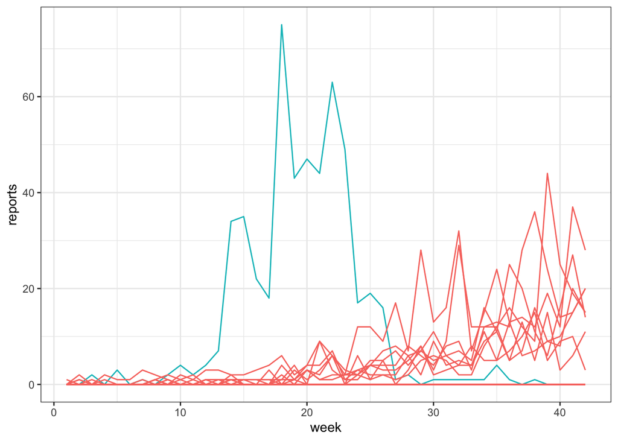

```r
set.seed(1014406)
measSEIR %>%
  simulate(nsim=20,format="data.frame",include.data=TRUE) %>%
  ggplot(aes(x=week,y=reports,group=.id,color=(.id=="data")))+
  geom_line()+
  guides(color="none")+
  theme_bw()
```

The next prerequisite is that we can successfully filter:

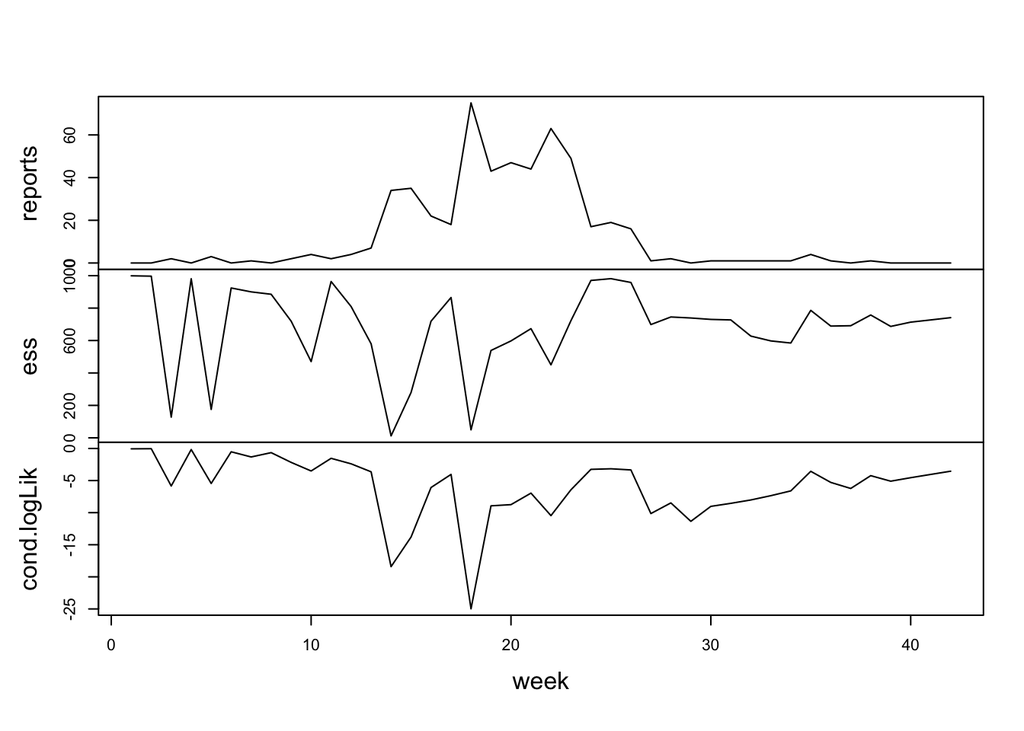

```r
pf1 <- pfilter(measSEIR,Np=1000)
plot(pf1)
```

```r
logLik(pf1)
```

```
## [1] -251.9792
```

The minimum effective sample size is 12, which is not a complete disaster, and we should bear in mind that this is likely to improve when we fit the parameters.

- The computation time depends on how many profile points to calculate, how many replicated searches to do at each point. Here, we use the run level approach described in Chapter 16 of [2].

```r
  run_level <- 3
  Np <-              switch(run_level,100, 1e3, 2e3)
  Nlocal <-          switch(run_level,  2,   5,  20)
  Nglobal <-         switch(run_level,  2,   5, 100)
  Npoints_profile <- switch(run_level,  4,  10,  50)
  Nreps_profile   <- switch(run_level,  2,   4,  15)
  Nmif <-            switch(run_level, 10,  50, 100)
  Nreps_eval <-      switch(run_level,  2,   5,  10)
```

- We set up a directory for saving cached results, and an environment for parallel computation which is set up to run on either a single machine or a single node of a slurm cluster.

```r
library(doParallel)
cores <- as.numeric(Sys.getenv('SLURM_NTASKS_PER_NODE',unset=NA))
if(is.na(cores)) cores <- detectCores()
registerDoParallel(cores)
results_dir <- paste0("laptop_",run_level,"/")
#results_dir <- paste0("greatlakes_",run_level,"/")
if(!dir.exists(results_dir)) dir.create(results_dir)
bake(file=paste0(results_dir,"cores.rds"),cores) -> cores
```

- We set up a parallel random number generator and set a seed for reproducibility.

```r
library(doRNG)
registerDoRNG(482947940)
```

```r
sapply(mifs_local,logLik)
```

```
##  [1] -105.0777 -105.0846 -105.0534 -104.8985 -105.4747 -105.2934 -105.0920
##  [8] -105.1716 -105.3109 -105.1219 -105.1779 -105.3092 -105.3874 -105.0554
## [15] -105.2412 -105.1621 -105.0038 -104.9770 -105.2934 -105.0516
```

As usual, we should evaluate the likelihoods using a particle filter, rather than relying on the likelihood from the last filtering iteration of the perturbed model used by `mif2`.

```r
registerDoRNG(900242057)
foreach(mf=mifs_local,.combine=rbind) %dopar% {
  library(pomp)
  library(tidyverse)
  evals <- replicate(Nreps_eval, logLik(pfilter(mf,Np=Np)))
  ll <- logmeanexp(evals,se=TRUE)
  mf %>% coef() %>% bind_rows() %>%
    bind_cols(loglik=ll[1],loglik.se=ll[2])
} -> local_logliks
```

In this case, there is not much discrepancy between the perturbed and unperturbed likelihoods. The small improvement (rather than disadvantage) from filtering with fixed parameters supports a hypothesis that the constant parameter model is reasonable here.

```r
local_logliks$loglik
```

```
##       est       est       est       est       est       est       est       est
## -104.3919 -104.4448 -104.3445 -104.3449 -104.5191 -104.4507 -104.3988 -104.5510
##       est       est       est       est       est       est       est       est
## -104.4784 -104.3914 -104.4968 -104.6741 -104.2500 -104.4285 -104.1843 -104.3976
##       est       est       est       est
## -104.3819 -104.4062 -104.4856 -104.5578
```

```r
set.seed(2062379496)

runif_design(
  lower=c(Beta=5,rho=0.2,eta=0,mu_EI=1/3),
  upper=c(Beta=80,rho=0.9,eta=1,mu_EI=3),
  nseq=Nglobal
) -> guesses
mf1 <- mifs_local[[1]]
```

```r
bake(file=paste0(results_dir,"global_search.rds"),{
registerDoRNG(1270401374)
foreach(guess=iter(guesses,"row"), .combine=rbind) %dopar% {
  library(pomp)
  library(tidyverse)
  mf1 %>%
    mif2(params=c(unlist(guess),fixed_params),Np=Np) %>%
    mif2() -> mf
  replicate(
    Nreps_eval,
    mf %>% pfilter(Np=Np) %>% logLik()
  ) %>%
    logmeanexp(se=TRUE) -> ll
  mf %>% coef() %>% bind_rows() %>%
    bind_cols(loglik=ll[1],loglik.se=ll[2])
} -> results
}) %>%
  filter(is.finite(loglik)) -> results
```

### (b). Comparison of SEIR and SIR likelihoods

The maximum log likelihood discovered is -103.6. This small improvement of around one log unit is not compelling evidence by itself for the need of an extra parameter.

### (c). Interpretation of the SEIR fitted model

The fitted model has some interesting features, which can be seen from a scatter plot.

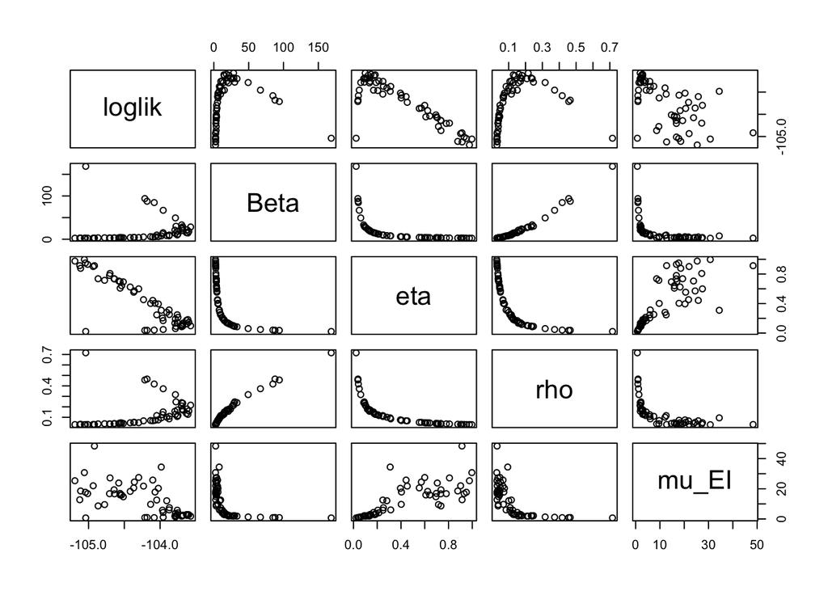

```r
pairs(~loglik+Beta+eta+rho+mu_EI,
      data=filter(results,loglik>max(loglik)-10))
```

When including an latent period, the MLE has intermediate values of $\rho$ and $\eta$ that match epidemiological expectations for endemic measles in the pre-vaccine era, while remaining consistent with a mean infectious period of 0.5 wk. This is substantially different from the results in Section 5 of Lesson 4. Thus, adding a latent period to the model can substantially change the interpretation of the fitted model without substantially changing the overall fit measured by maximized likelihood. The profile likelihood calculations below help to clarify this finding.

The likelihood surface here is fairly flat: the y-axis range is just 2 log units. Data on a single epidemic cannot readily distinguish whether the disease has a high susceptible fraction and low reporting rate, or low susceptible fraction and high reporting rate. Longer time series could resolve this question.

### (d). Calculating and plotting a profile likelihood for reporting rate.

Here, we follow the profile code in Chapter 14 of the course notes [2] which draws on [1].

- Recall that profiling means determining, for each value of $\rho$, the best likelihood that the model can achieve.
- To do this, we’ll first bound the uncertainty by putting a box around the highest-likelihood estimates we’ve found so far.
- Within this box, we’ll choose some random starting points, for each of several values of $\rho$.

```r
  filter(results,loglik>max(loglik)-20) %>%
    sapply(range) -> box
  box
```

```
##            Beta        rho        eta      mu_EI     N mu_IR  k    loglik
## [1,]   1.734629 0.02936271 0.02233601  0.7094618 38000     2 10 -119.8806
## [2,] 168.559655 0.94014333 0.99671126 48.3440159 38000     2 10 -103.5724
##       loglik.se
## [1,] 0.02837331
## [2,] 0.49851575
```

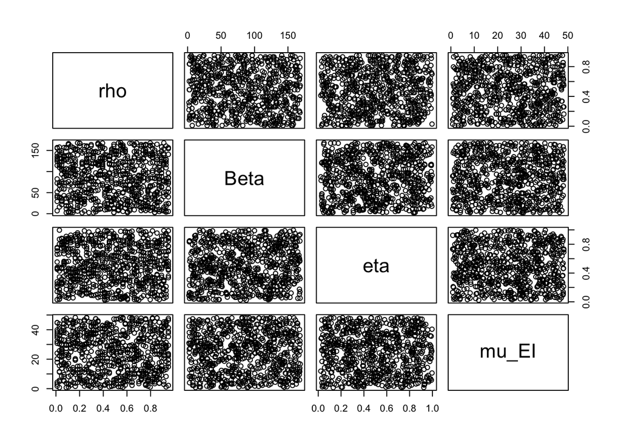

```r
  freeze(seed=1196696958,
    profile_design(
      rho =seq(0.01,0.95,length=Npoints_profile),
      lower=box[1,c("Beta","eta","mu_EI")],
      upper=box[2,c("Beta","eta","mu_EI")],
      nprof=Nreps_profile, type="runif"
    )) -> guesses
  plot(guesses)
```

```r
  fixed_params <- c(N=38000, mu_IR=2, k=10)
```

```r
bake(file=paste0(results_dir,"rho_profile.rds"),dependson=guesses,{
  registerDoRNG(2105684752)
  foreach(guess=iter(guesses,"row"), .combine=rbind) %dopar% {
    library(pomp)
    library(tidyverse)
    mf1 %>% mif2(params=c(guess,fixed_params),Nmif=Nmif,
      rw.sd=rw_sd(Beta=0.02,eta=ivp(0.02),mu_EI=0.02)) %>%
      mif2(Nmif=Nmif,Np=Np,cooling.fraction.50=0.3) -> mf
    replicate(
      Nreps_eval,
      mf %>% pfilter(Np=Np) %>% logLik()) %>%
      logmeanexp(se=TRUE) -> ll
    mf %>% coef() %>% bind_rows() %>%
      bind_cols(loglik=ll[1],loglik.se=ll[2])
  } -> prof_results
  attr(prof_results,"ncpu") <- getDoParWorkers()
  prof_results
}) -> profile_results

t_rho <- attr(profile_results,"system.time")
ncpu_rho <- attr(profile_results,"ncpu")
```

The profile took 29 min to run on 8 cores.

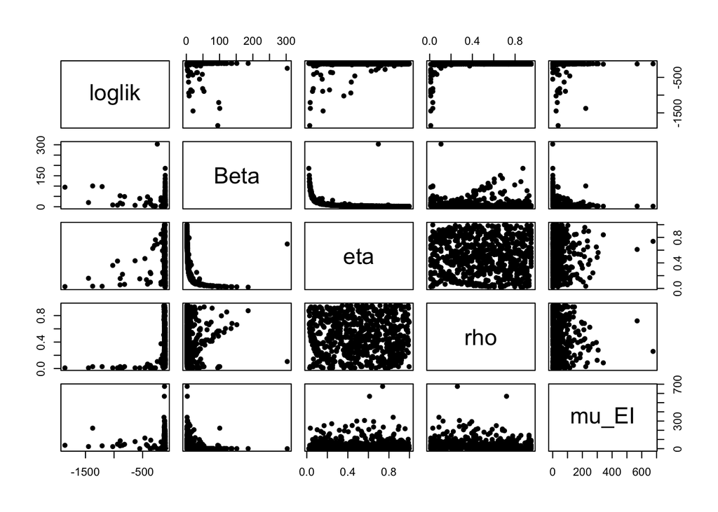

```r
  profile_results %>%
    filter(is.finite(loglik)) -> profile_results

  pairs(~loglik+Beta+eta+rho+mu_EI,data=profile_results,pch=16)
```

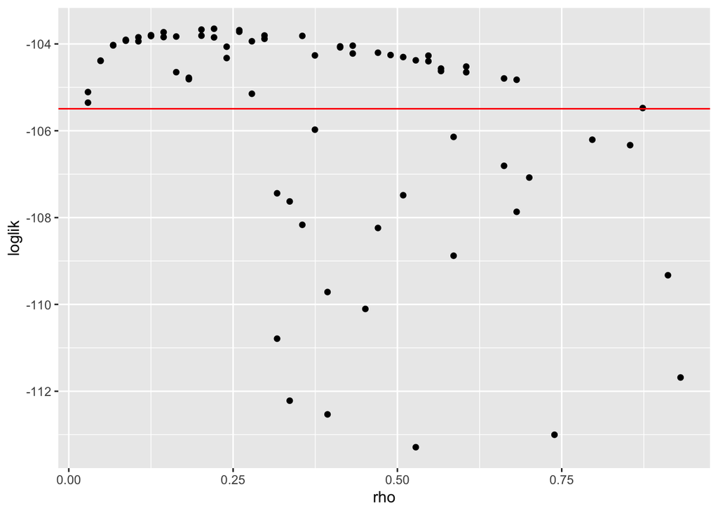

```r
  profile_results %>%
    filter(loglik>max(loglik)-10) %>%
    group_by(round(rho,2)) %>%
    filter(rank(-loglik)<3) %>%
    ungroup() %>%
    ggplot(aes(x=rho,y=loglik))+
    geom_point()+
    geom_hline(
      color="red",
      yintercept=max(results$loglik)-0.5*qchisq(df=1,p=0.95)
    )
```

```r
  profile_results %>%
    filter(loglik>max(loglik)-0.5*qchisq(df=1,p=0.95)) %>%
    summarize(min=min(rho),max=max(rho)) -> rho_ci
```

According to this model, the data are consistent with reporting efficiencies in the 2.9 – 87 percent range (95% CI)`.

We can compare to the profile over $\rho$ on [2] Chapter 15, slide 76, which obtains an approximate confidence interval of 3–17% for $\rho$ when there is no latent period.

Including the latent period therefore allows us to fit the data with a model matching our anticipation that infectious period should be around 3.5 days and reporting rate around 60%.

### (e). Run time.

```r
end_time <- Sys.time()
bake(file=paste0(results_dir,"run_time.rds"),difftime(end_time,start_time,units="secs")) -> run_time
```

- On a MacBook Air laptop, the SEIR computations took 6.3 min at run level 2, with 4 cores.
- At run level 3, a MacBook Pro M4 laptop took 35 min with 8 cores.
- For running long jobs on a laptop, it can be useful to use `nohup` and `&` to run the job in the background, regardless of the fate of the terminal where it was started.

```
nohup Rscript --vanilla -e "rmarkdown::render(\"sol07.Rmd\")" &
```

- However, you also have to stop your laptop powering down. Even then, it is not very practical. This homework is around the limit of what can be done readily on a modern laptop. It is time to use a cluster.
- On greatlakes, the computation time was 57 sec at run level 2, and 22 min at run level 3, with 36 cores.
- The sbat files used to run the code on greatlakes are `run1.sbat`, `run2.sbat`, `run3.sbat` in the source directory. They compile the document using `knitr::knit()` rather than `` rmarkdown::render()`` since the latter needs an additional program ( ``pandoc`) to convert the results to HTML.`knit` will run the code and save the results of the computations, which can then be copied back to your laptop for compilation to HTML.

## Acknowledgment

This solution builds on DATASCI/STATS 531 solutions from previous semesters.

## References

1.

King, A.A., Ionides, E.L., and Lin, Q. (2023). [Simulation-based inference for epidemiological dynamics](https://kingaa.github.io/sbied/). Summer Institute in Statistics and Modeling in Infectious Diseases.

2.

Ionides, E. (2025). [Notes for STATS/DATASCI 531, Modeling and Analysis of Time Series Data](https://ionides.github.io/531w25/).